# Homework 7 Programming Answer

### IST 5520, 2022 Fall

**Instruction:**

Complete the following tasks and type your answers to questions directly on the jupyter notebook. You can add additional code lines if necessary.

```python
# Import modules and set inline mode
import pandas as pd
import numpy as np
from sklearn.decomposition import PCA
import matplotlib.pyplot as plt
from sklearn.preprocessing import scale
%matplotlib inline
```

# Task: Principal Component Analysis of the Wine Dataset

(1) Load Wine Dataset

The data file 'wine.data' is the result of a chemical analysis of wines grown in the same region in Italy but derived from three different cultivars. The analysis determined the quantities of 13 constituents found in each of the three types of wines.

The first column is the class of the wine, other columns are attributes of the wine. These columns are:

- 1) Class
- 2) Alcohol
- 3) Malic acid
- 4) Ash
- 5) Alcalinity of ash
- 6) Magnesium
- 7) Total phenols
- 8) Flavanoids
- 9) Nonflavanoid phenols
- 10) Proanthocyanins
- 11) Color intensity
- 12) Hue
- 13) OD280/OD315 of diluted wines
- 14) Proline

For detailed description of the dataset, refer to https://archive.ics.uci.edu/ml/datasets/Wine.

Create a pandas DataFrame from the data file. The data file itself does not include column names, so you need to manually set the column names for your DataFrame. Then show information of the dataset.

Tip: Set the header parameter of the pd.read_csv() function correctly so that the first row will not be treated as column header.

```python
df = pd.read_csv('..\Data\wine.data',header=None)
df.columns = ['Class','Alcohol','Malic Acid','Ash','Alcalinity of Ash',
              'Magnesium','Total Phenols','Flavanoids','Nonflavanoid Phenols',
              'Proanthocyanins','Color Intensity','Hue',
              'OD280/OD315 of Diluted Wines','Proline']
df.info()
```

```
<class 'pandas.core.frame.DataFrame'>
RangeIndex: 178 entries, 0 to 177
Data columns (total 14 columns):
 #   Column                        Non-Null Count  Dtype
---  ------                        --------------  -----
 0   Class                         178 non-null    int64
 1   Alcohol                       178 non-null    float64
 2   Malic Acid                    178 non-null    float64
 3   Ash                           178 non-null    float64
 4   Alcalinity of Ash             178 non-null    float64
 5   Magnesium                     178 non-null    int64
 6   Total Phenols                 178 non-null    float64
 7   Flavanoids                    178 non-null    float64
 8   Nonflavanoid Phenols          178 non-null    float64
 9   Proanthocyanins               178 non-null    float64
 10  Color Intensity               178 non-null    float64
 11  Hue                           178 non-null    float64
 12  OD280/OD315 of Diluted Wines  178 non-null    float64
 13  Proline                       178 non-null    int64
dtypes: float64(11), int64(3)
memory usage: 19.6 KB
```

**Question 1**: How many observations are in the dataset? Does the dataset contain missing values?

Your Answer: 178 observations are included in the dataset. There is no missing value.

(2) Sample observations

Randomly select 5 obvervations from the dataset and show them below.

```python
df.sample(5).transpose()
```

|  | 10 | 101 | 132 | 130 | 31 |
| --- | --- | --- | --- | --- | --- |
| Class | 1.00 | 2.00 | 3.00 | 3.00 | 1.00 |
| Alcohol | 14.10 | 12.60 | 12.81 | 12.86 | 13.58 |
| Malic Acid | 2.16 | 1.34 | 2.31 | 1.35 | 1.66 |
| Ash | 2.30 | 1.90 | 2.40 | 2.32 | 2.36 |
| Alcalinity of Ash | 18.00 | 18.50 | 24.00 | 18.00 | 19.10 |
| Magnesium | 105.00 | 88.00 | 98.00 | 122.00 | 106.00 |
| Total Phenols | 2.95 | 1.45 | 1.15 | 1.51 | 2.86 |
| Flavanoids | 3.32 | 1.36 | 1.09 | 1.25 | 3.19 |
| Nonflavanoid Phenols | 0.22 | 0.29 | 0.27 | 0.21 | 0.22 |
| Proanthocyanins | 2.38 | 1.35 | 0.83 | 0.94 | 1.95 |
| Color Intensity | 5.75 | 2.45 | 5.70 | 4.10 | 6.90 |
| Hue | 1.25 | 1.04 | 0.66 | 0.76 | 1.09 |
| OD280/OD315 of Diluted Wines | 3.17 | 2.77 | 1.36 | 1.29 | 2.88 |
| Proline | 1510.00 | 562.00 | 560.00 | 630.00 | 1515.00 |

(3) Convert the value of Class variable

Convert Class integer values into strings by using the following mapping:

- 1: 'Class 1'
- 2: 'Class 2'
- 3: 'Class 3'

```python
df['Class'] = df.Class.map({1:'Class 1', 2:'Class 2', 3: 'Class 3'})
```

(4) Normalize dataset

Standardize all columns except Class so that these columns have mean = 0 and standard error = 1.

```python
data_norm = scale(df.loc[:,'Alcohol':'Proline'])
data_norm = pd.DataFrame(data_norm)
data_norm.describe()
```

|  | 0 | 1 | 2 | 3 | 4 | 5 | 6 | 7 | 8 | 9 | 10 | 11 | 12 |
| --- | --- | --- | --- | --- | --- | --- | --- | --- | --- | --- | --- | --- | --- |
| count | 1.780000e+02 | 1.780000e+02 | 1.780000e+02 | 1.780000e+02 | 1.780000e+02 | 178.000000 | 1.780000e+02 | 1.780000e+02 | 1.780000e+02 | 1.780000e+02 | 1.780000e+02 | 1.780000e+02 | 1.780000e+02 |
| mean | -8.382808e-16 | -1.197544e-16 | -8.370333e-16 | -3.991813e-17 | -3.991813e-17 | 0.000000 | -3.991813e-16 | 3.592632e-16 | -1.197544e-16 | 2.494883e-17 | 1.995907e-16 | 3.193450e-16 | -1.596725e-16 |
| std | 1.002821e+00 | 1.002821e+00 | 1.002821e+00 | 1.002821e+00 | 1.002821e+00 | 1.002821 | 1.002821e+00 | 1.002821e+00 | 1.002821e+00 | 1.002821e+00 | 1.002821e+00 | 1.002821e+00 | 1.002821e+00 |
| min | -2.434235e+00 | -1.432983e+00 | -3.679162e+00 | -2.671018e+00 | -2.088255e+00 | -2.107246 | -1.695971e+00 | -1.868234e+00 | -2.069034e+00 | -1.634288e+00 | -2.094732e+00 | -1.895054e+00 | -1.493188e+00 |
| 25% | -7.882448e-01 | -6.587486e-01 | -5.721225e-01 | -6.891372e-01 | -8.244151e-01 | -0.885468 | -8.275393e-01 | -7.401412e-01 | -5.972835e-01 | -7.951025e-01 | -7.675624e-01 | -9.522483e-01 | -7.846378e-01 |
| 50% | 6.099988e-02 | -4.231120e-01 | -2.382132e-02 | 1.518295e-03 | -1.222817e-01 | 0.095960 | 1.061497e-01 | -1.760948e-01 | -6.289785e-02 | -1.592246e-01 | 3.312687e-02 | 2.377348e-01 | -2.337204e-01 |
| 75% | 8.361286e-01 | 6.697929e-01 | 6.981085e-01 | 6.020883e-01 | 5.096384e-01 | 0.808997 | 8.490851e-01 | 6.095413e-01 | 6.291754e-01 | 4.939560e-01 | 7.131644e-01 | 7.885875e-01 | 7.582494e-01 |
| max | 2.259772e+00 | 3.109192e+00 | 3.156325e+00 | 3.154511e+00 | 4.371372e+00 | 2.539515 | 3.062832e+00 | 2.402403e+00 | 3.485073e+00 | 3.435432e+00 | 3.301694e+00 | 1.960915e+00 | 2.971473e+00 |

```python
data_norm.head()
```

|  | 0 | 1 | 2 | 3 | 4 | 5 | 6 | 7 | 8 | 9 | 10 | 11 | 12 |
| --- | --- | --- | --- | --- | --- | --- | --- | --- | --- | --- | --- | --- | --- |
| 0 | 1.518613 | -0.562250 | 0.232053 | -1.169593 | 1.913905 | 0.808997 | 1.034819 | -0.659563 | 1.224884 | 0.251717 | 0.362177 | 1.847920 | 1.013009 |
| 1 | 0.246290 | -0.499413 | -0.827996 | -2.490847 | 0.018145 | 0.568648 | 0.733629 | -0.820719 | -0.544721 | -0.293321 | 0.406051 | 1.113449 | 0.965242 |
| 2 | 0.196879 | 0.021231 | 1.109334 | -0.268738 | 0.088358 | 0.808997 | 1.215533 | -0.498407 | 2.135968 | 0.269020 | 0.318304 | 0.788587 | 1.395148 |
| 3 | 1.691550 | -0.346811 | 0.487926 | -0.809251 | 0.930918 | 2.491446 | 1.466525 | -0.981875 | 1.032155 | 1.186068 | -0.427544 | 1.184071 | 2.334574 |
| 4 | 0.295700 | 0.227694 | 1.840403 | 0.451946 | 1.281985 | 0.808997 | 0.663351 | 0.226796 | 0.401404 | -0.319276 | 0.362177 | 0.449601 | -0.037874 |

(5) Principal component analysis with full components

```python
# Select the number of components
pca1 = PCA(n_components=13)

# Fit the PCA model
pca1.fit(data_norm)
```

```
PCA(n_components=13)
```

```python
#The amount of variance that each PC explains
var = pca1.explained_variance_ratio_

#Cumulative Variance explains
var1 = np.cumsum(np.round(pca1.explained_variance_ratio_, decimals=4)*100)

print(var1)
```

```
[ 36.2   55.41  66.53  73.6   80.16  85.1   89.34  92.02  94.24  96.17
  97.91  99.21 100.01]
```

(6) Draw a scree plot to show the cumulative variance explained along the number of principal components.

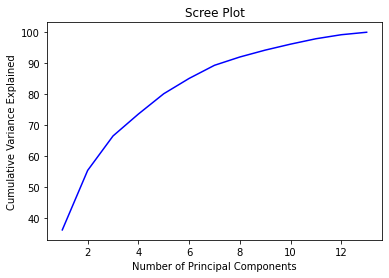

```python
var1 = pd.DataFrame(var1, index=np.arange(1,14))
plt.plot(var1,color='blue')
plt.title('Scree Plot')
plt.xlabel('Number of Principal Components')
plt.ylabel('Cumulative Variance Explained')
plt.savefig('scree_plot.png',dpi=100,bbox_inches='tight')
```

**Question 2**: What is the least number of components we need to keep in order to keep 90% variance of the original predictors?

Your answer:

8

(7) Principal component analysis with two componenets.

```python
# Select the number of components
pca2 = PCA(n_components=2)
pca2.fit(data_norm)
data_pca2 = pca2.fit_transform(data_norm)

# Convert the numpy array to pandas DataFrame
data_pca2 = pd.DataFrame(data_pca2)
data_pca2.columns = ["PC"+str(i) for i in range(1,3)]

# Show the head of the DataFrame
data_pca2.head()
```

|  | PC1 | PC2 |
| --- | --- | --- |
| 0 | 3.316751 | -1.443463 |
| 1 | 2.209465 | 0.333393 |
| 2 | 2.516740 | -1.031151 |
| 3 | 3.757066 | -2.756372 |
| 4 | 1.008908 | -0.869831 |

(8) Run a correlation analysis on the dimension-reduced dataset.

```python
import scipy as sp
sp.stats.pearsonr(data_pca2['PC1'],data_pca2['PC2'])
```

```
(1.3877787807814457e-16, 0.999999999999894)
```

**Question 3**: What conclusion do you get from the correlation analysis?

Your answer:

Although the original predictors are correlated, principal components are orthogonal (not correlated, pearson correlation = 0.000, p-value = 1.0). This is because the principal component analysis applies an orthogonal rotation.

(9) Plot wine class onto the reduced two-dimensional space.

With the two-component solution, draw a scatter plot to show the reduced dataset. Actually, one popular use of PCA is to reduce dimension to two, thus allowing plot a multi-dimensional data on a 2D space.

The scatter plot should use "Principal Component 1" as x axis, "Principal Component 2" as y axis. Use different colors to represent points for different classes of the wine.

A sample scatter plot can be found here: https://mst.instructure.com/files/2002770/download?download_frd=1

You can refer to "Data Summarization and Visualization" jupyter notebook section 4.6 for scatter plot.

```python
pca2_df = pd.concat([data_pca2, df['Class']],axis=1)

pca2_df.head()
```

|  | PC1 | PC2 | Class |
| --- | --- | --- | --- |
| 0 | 3.316751 | -1.443463 | Class 1 |
| 1 | 2.209465 | 0.333393 | Class 1 |
| 2 | 2.516740 | -1.031151 | Class 1 |
| 3 | 3.757066 | -2.756372 | Class 1 |
| 4 | 1.008908 | -0.869831 | Class 1 |

We can use the matplotlib package to draw the plot.

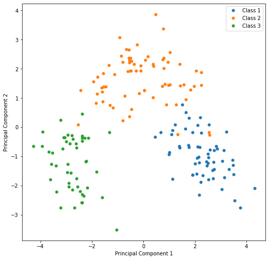

```python
# Generate grouped data first
grouped = pca2_df.groupby('Class')

# Then draw the plot by group
fig, ax = plt.subplots(figsize=(8.5,8.5))
for name, group in grouped:
    ax.plot(group.PC1, group.PC2, marker='o', linestyle='', ms=5, label=name)
ax.legend(['Class 1','Class 2','Class 3'])
plt.xlabel('Principal Component 1')
plt.ylabel('Principal Component 2')
plt.savefig('HW7_2D_plot.png', dpi=100,bbox_inches='tight')
plt.show()
```

An alternative is to use the seaborn package to draw the plot. The syntax seems simpler.

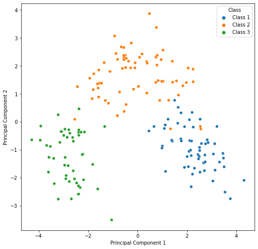

```python
# Use seaborn to draw the scatterplot
import seaborn as sb

plt.figure(figsize=(8.5, 8.5))
sb.scatterplot(x='PC1', y='PC2', hue='Class', data=pca2_df)
plt.xlabel('Principal Component 1')
plt.ylabel('Principal Component 2')
plt.show()
```

**Question 4**: According to the scatter plot shown above, are these two principal components good predictors for classifying wine class? Explain why.

Your answer:

From the above scatter plot, we can find that the two principal components can seperate the three wine classes very nicely. Thus, the two principal components are good predictors for classifying wine class.